# Home-Credit EDA Workbook

```r
# summary of annuity payments. Mean appears to be influence by outliers on the high end to the tune of $3,000.
summary(training_data$AMT_ANNUITY)
```

```
##    Min. 1st Qu.  Median    Mean 3rd Qu.    Max.    NA's
##    1616   16524   24903   27109   34596  258026      12
```

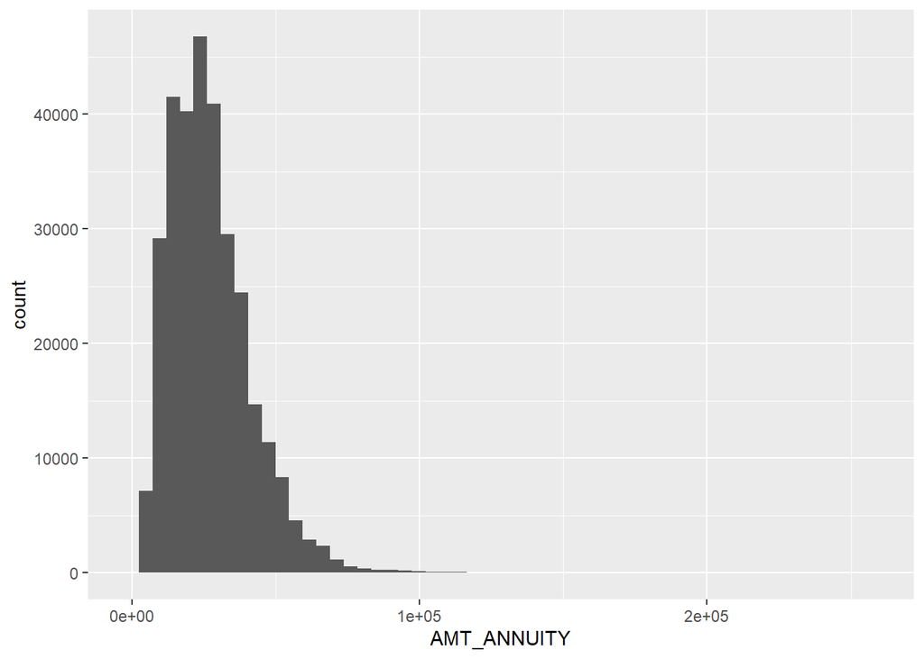

```r
#plot distribution of AMT_ANNUITY values
ggplot(training_data, aes(x = AMT_ANNUITY)) + geom_histogram(bins = 55)
```

By applying the glm function in the three main variables (AMT_INCOME_TOTAL, AMT_CREDIT, AMT_ANNUITY) we initially believed could be predictors of target. In individual binomial regressions, each of the three features were statistically significant at the p<.001 threshold. When all the variables were included in the model, the p value for AMT_INCOME_TOTAL fell below an acceptable level at p = 0.42.

```r
#Plotting target against income with a summary linear regression line:
(lm_model1 <-glm(TARGET ~ AMT_INCOME_TOTAL, family=binomial, data = training_data)) %>%
  summary
```

```
##
## Call:
## glm(formula = TARGET ~ AMT_INCOME_TOTAL, family = binomial, data = training_data)
##
## Deviance Residuals:
##     Min       1Q   Median       3Q      Max
## -0.4191  -0.4137  -0.4109  -0.4067   8.4904
##
## Coefficients:
##                    Estimate Std. Error  z value Pr(>|z|)
## (Intercept)      -2.380e+00  1.348e-02 -176.495  < 2e-16 ***
## AMT_INCOME_TOTAL -3.142e-07  7.085e-08   -4.435 9.23e-06 ***
## ---
## Signif. codes:  0 '***' 0.001 '**' 0.01 '*' 0.05 '.' 0.1 ' ' 1
##
## (Dispersion parameter for binomial family taken to be 1)
##
##     Null deviance: 172542  on 307510  degrees of freedom
## Residual deviance: 172515  on 307509  degrees of freedom
## AIC: 172519
##
## Number of Fisher Scoring iterations: 6
```

```r
# Plotting target against credit with a summary linear regression line:
(lm_model2 <-glm(TARGET ~ AMT_CREDIT, family=binomial, data = training_data)) %>%
  summary
```

```
##
## Call:
## glm(formula = TARGET ~ AMT_CREDIT, family = binomial, data = training_data)
##
## Deviance Residuals:
##     Min       1Q   Median       3Q      Max
## -0.4424  -0.4278  -0.4123  -0.3898   2.6380
##
## Coefficients:
##               Estimate Std. Error z value Pr(>|z|)
## (Intercept) -2.262e+00  1.185e-02 -190.94   <2e-16 ***
## AMT_CREDIT  -2.946e-07  1.751e-08  -16.82   <2e-16 ***
## ---
## Signif. codes:  0 '***' 0.001 '**' 0.01 '*' 0.05 '.' 0.1 ' ' 1
##
## (Dispersion parameter for binomial family taken to be 1)
##
##     Null deviance: 172542  on 307510  degrees of freedom
## Residual deviance: 172247  on 307509  degrees of freedom
## AIC: 172251
##
## Number of Fisher Scoring iterations: 5
```

```r
# Plotting target against annuity with a summary linear regression line:
(lm_model3 <-glm(TARGET ~ AMT_ANNUITY, family=binomial, data = training_data)) %>%
  summary
```

```
##
## Call:
## glm(formula = TARGET ~ AMT_ANNUITY, family = binomial, data = training_data)
##
## Deviance Residuals:
##     Min       1Q   Median       3Q      Max
## -0.4272  -0.4168  -0.4107  -0.4027   2.4079
##
## Coefficients:
##               Estimate Std. Error  z value Pr(>|z|)
## (Intercept) -2.343e+00  1.414e-02 -165.632  < 2e-16 ***
## AMT_ANNUITY -3.349e-06  4.710e-07   -7.109 1.17e-12 ***
## ---
## Signif. codes:  0 '***' 0.001 '**' 0.01 '*' 0.05 '.' 0.1 ' ' 1
##
## (Dispersion parameter for binomial family taken to be 1)
##
##     Null deviance: 172540  on 307498  degrees of freedom
## Residual deviance: 172488  on 307497  degrees of freedom
##   (12 observations deleted due to missingness)
## AIC: 172492
##
## Number of Fisher Scoring iterations: 5
```

```r
# Combining the features
(lm_model3 <-glm(TARGET ~ AMT_ANNUITY + AMT_CREDIT + AMT_INCOME_TOTAL, family=binomial, data = training_data)) %>%
  summary
```

```
##
## Call:
## glm(formula = TARGET ~ AMT_ANNUITY + AMT_CREDIT + AMT_INCOME_TOTAL,
##     family = binomial, data = training_data)
##
## Deviance Residuals:
##     Min       1Q   Median       3Q      Max
## -0.5312  -0.4259  -0.4133  -0.3866   4.2702
##
## Coefficients:
##                    Estimate Std. Error  z value Pr(>|z|)
## (Intercept)      -2.325e+00  1.506e-02 -154.372   <2e-16 ***
## AMT_ANNUITY       6.869e-06  7.206e-07    9.533   <2e-16 ***
## AMT_CREDIT       -4.864e-07  2.684e-08  -18.122   <2e-16 ***
## AMT_INCOME_TOTAL -5.725e-08  7.096e-08   -0.807     0.42
## ---
## Signif. codes:  0 '***' 0.001 '**' 0.01 '*' 0.05 '.' 0.1 ' ' 1
##
## (Dispersion parameter for binomial family taken to be 1)
##
##     Null deviance: 172540  on 307498  degrees of freedom
## Residual deviance: 172154  on 307495  degrees of freedom
##   (12 observations deleted due to missingness)
## AIC: 172162
##
## Number of Fisher Scoring iterations: 5
```

## Contract Type

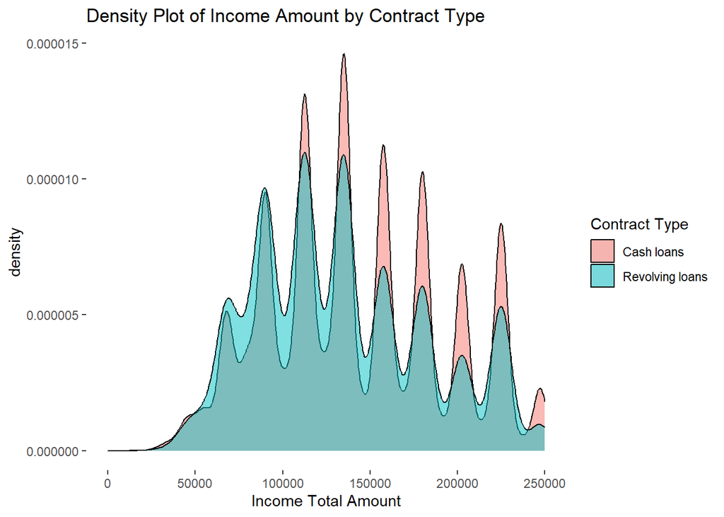

```r
options(scipen = 999)

plot2 <- training_data %>%
   filter(AMT_INCOME_TOTAL < 117000000) %>%
  ggplot(aes(x = AMT_INCOME_TOTAL, fill = NAME_CONTRACT_TYPE)) +
  geom_density(alpha = 0.5) +
    theme(panel.grid.major = element_blank(),
        panel.grid.minor = element_blank(),
        panel.border = element_blank(),
        panel.background = element_blank()) +
  labs(title = "Density Plot of Income Amount by Contract Type", x = "Income Total Amount", fill = "Contract Type")

plot2 <- plot2 + xlim(0, 250000)

plot2
```

## Annuity

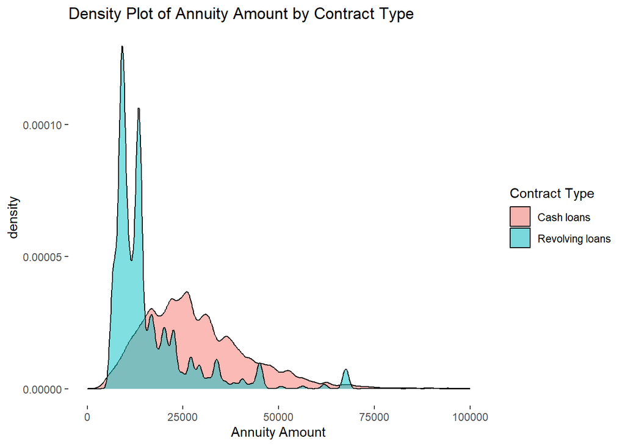

```r
# Set the axis labels and limits
plot <- ggplot(training_data, aes(x = AMT_ANNUITY, fill = NAME_CONTRACT_TYPE)) +
  geom_density(alpha = 0.5) +
  theme(panel.grid.major = element_blank(),
        panel.grid.minor = element_blank(),
        panel.border = element_blank(),
        panel.background = element_blank()) +
  labs(title = "Density Plot of Annuity Amount by Contract Type", x = "Annuity Amount", fill = "Contract Type")

plot <- plot + xlim(0, 100000)

# Display the plot
plot
```

## Credit and Housing Type

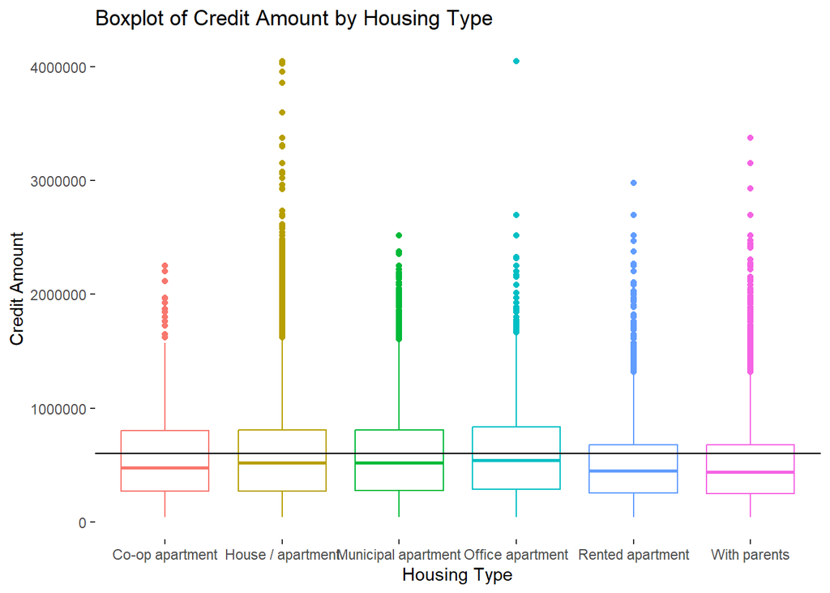

```r
amt_credit_bp <- ggplot(training_data,
       aes(x = NAME_HOUSING_TYPE, y = AMT_CREDIT, color = NAME_HOUSING_TYPE)) +
  geom_boxplot(fill = "white") +
  theme(panel.grid.major = element_blank(),
        panel.grid.minor = element_blank(),
        panel.border = element_blank(),
        panel.background = element_blank()) +
  labs(title = "Boxplot of Credit Amount by Housing Type", x = "Housing Type", y = "Credit Amount") +
  guides(color = FALSE)
amt_credit_bp_w_line <- amt_credit_bp +
  geom_hline(aes(yintercept = mean(AMT_CREDIT)), color = "black")

amt_credit_bp_w_line
```

## Annuity and Income Type Relationship

Another variable we thought could show an interesting relationship with the Target variable is income type as it can represent socioeconomic status to a degree as well as current job status. At a first glance, this visualization shows a wide range of annuity’s given to bussiness men with the maximum values being given to commerical associates. We plan to further analysis the relationship between income type and the target variable specifically, but we believe that annuity amount will be an important predictor in the dataset so we wanted to illustrate its relationship to income type in our initial analysis.

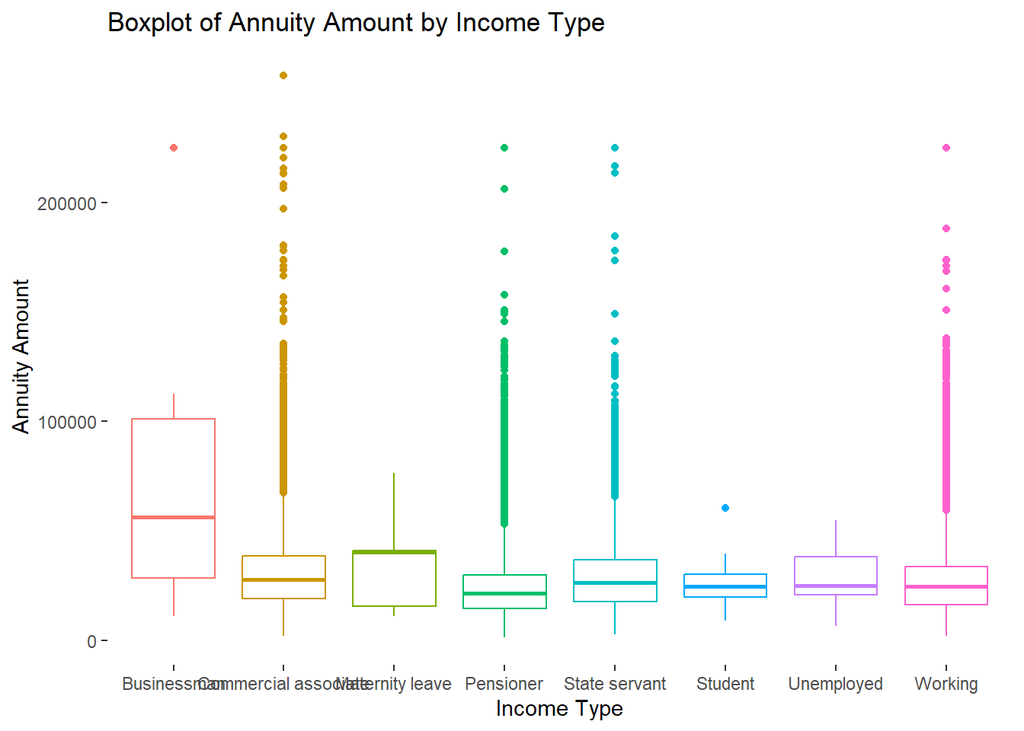

```r
amt_annuity_bp <- ggplot(training_data,
       aes(x = NAME_INCOME_TYPE, y = AMT_ANNUITY, color = NAME_INCOME_TYPE)) +
  geom_boxplot(fill = "white") +
  theme(panel.grid.major = element_blank(),
        panel.grid.minor = element_blank(),
        panel.border = element_blank(),
        panel.background = element_blank()) +
  labs(title = "Boxplot of Annuity Amount by Income Type", x = "Income Type", y = "Annuity Amount") +
  guides(color = FALSE)

amt_annuity_bp
```

## Regionality

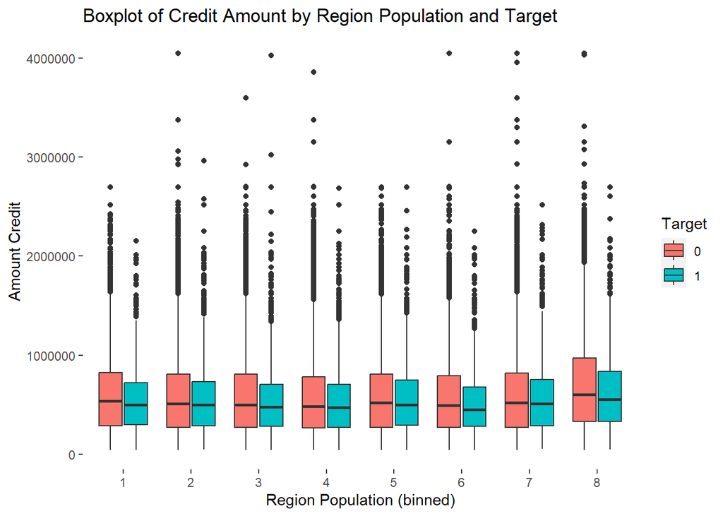

```r
# Define the breaks for binning
breaks <- c(0, 0.005, 0.01, 0.015, 0.02, 0.025, 0.03, 0.035, Inf)

# Bin the variable
binned_variable <- cut(training_data$REGION_POPULATION_RELATIVE, breaks = breaks, labels = FALSE, include.lowest = TRUE)

# Convert the binned variable back to a factor
binned_variable <- as.factor(binned_variable)

# Create a side-by-side boxplot
target_bp <- ggplot(training_data, aes(x = binned_variable, y = AMT_CREDIT, fill = as.factor(TARGET))) +
  geom_boxplot() +
  theme(panel.grid.major = element_blank(),
        panel.grid.minor = element_blank(),
        panel.border = element_blank(),
        panel.background = element_blank()) +
  labs(title = "Boxplot of Credit Amount by Region Population and Target", x = "Region Population (binned)", y = "Amount Credit", fill = "Target") +
  scale_fill_manual(values = c("#F8766D", "#00BFC4")) # Set custom fill colors

target_bp
```

# Merging Additional Tables

## Joining Bureau Table

While we are focused on the data readily available in the training set, we did want to take a closer look at borrowers’ other credit information. That can be found in the bureau table. We created a new table with the training table and the bureau table joined called “target_bureau” and visually examined the relationship between CREDIT_DAY_OVERDUE (the number of overdue days reported to the credit bureau by all lenders) and AMT_CREDIT (loan amount from Home Credit). We overlayed our target value. Most curret customers are well under 3 months delinquient (therefore not in the majority class), so we decided to focus on customers who are 90 days deliniqent with any creditor. There appears to be some correlation, but not a strong one in this relationship. This may be worth further examination in the modelling phase.

```r
#joining tables -- target & bureau tables
target_bureau <- merge(training_data, bureau, by="SK_ID_CURR")

#Summarizes the CREDIT_DAY_OVERDUE value, appears majority class = 0.
summary(bureau$CREDIT_DAY_OVERDUE)
```

```
##      Min.   1st Qu.    Median      Mean   3rd Qu.      Max.
##    0.0000    0.0000    0.0000    0.8182    0.0000 2792.0000
```

```r
#How many NAs are in this bureau variable? 0.
sum(is.na(bureau$CREDIT_DAY_OVERDUE))
```

```
## [1] 0
```

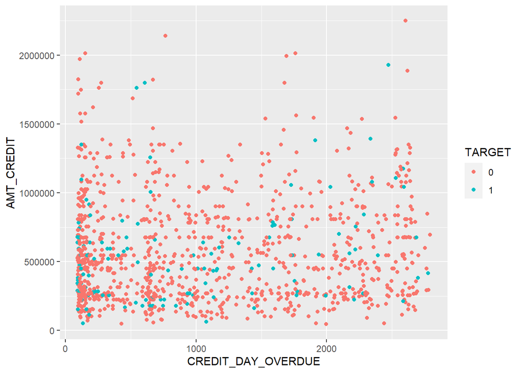

```r
#plot relationship between credit_day_overdue (all reported) and AMT credit (loan amount with Home Credit), categorized by target value.
target_bureau %>%
  filter(CREDIT_DAY_OVERDUE > 90) %>%
  ggplot(aes(x = CREDIT_DAY_OVERDUE, y = AMT_CREDIT, color = TARGET)) + geom_point()
```

# Initial Findings & Results

During this initial EDA stage of our Capstone Project, our team focused on getting possible insights on a individual level and them sharing ideas and discussions on how each of our analysis could improve our group EDA and help us determine important decisions for our next modeling phase. Karson Eilers focused on aggregating the transactional data, analysing missing values and performing initial exploratory analysis for the target variable. Paula Stefani focused on doing initial simple regression models in order to identify the strongest predictors of the target variable and identify the variables that would be more beneficial for the modeling stage. Jade Gosar focused on getting interesting insights by creating multiple plots in order to understand how the variables behave, for example by examining the NAME_HOUSING_TYPE variable and understanding the density levels of AMT_INCOME_TOTAL.

The main results of this initial EDA Stage were:

- Identification of the target variable (TARGET) we intend to use for the supervised regression model we will be creating in the modeling phase.
- Discussion on how we intend to handle the missing values on the datasets.
- Identification of the main datasets we intend to use for the modeling phase: application_{train|test}.csv, bureau.csv, and possibly previous_applications.csv if a wider sample is needed to correct for classification imbalance. .
- Determination of the main variables in the application_{train|test} dataset that we will want to use in order to implement in the future classification models: AMT_INCOME_TOTAL, AMT_CREDIT, AMT_ANNUITY, REG_REGION_NOT_LIVE_REGION, NAME_INCOME_TYPE, NAME_EDUCATION_TYPE, NAME_HOUSING_TYPE, OCCUPATION_TYPE.